# Objetivo 1: Análisis de la distribuición de los aeropuertos de EEUU y su tráfico aéreo

Joaquín Carrión Gil

2024-03-22

# 1. Preparación de Datos

## 1.1 Lectura de Ficheros

En este markdown podemos ver desarrollado el primer objetivo de nuestro proyecto, el cual tratará sobre estudiar los aeropuertos por cápita, por superficie y analizar la distribuición de los aeropuertos en los distintos estados de EEUU junto a su tráfico aéreo.

Lo primero que tenemos que hacer es leer el siguiente excel el cual contiene información de la superfície, el número de habitantes y el número de aeropuertos de cada uno de los estados; y un csv que contiene el número de vuelos por estado. Juntamos estos dos archivos en uno solo. Para construir el excel hemos utilizado técnicas de webscraping mediante el leguaje de programación python.

```r
aer_est= read_excel("C:/Users/ximoc/OneDrive - UPV/Escritorio/Proyecto 2/excel_estados_aeropuertos_poblacion.xlsx")
tabla=read_csv("tabla_estados.csv")
```

```
## ──────────────────────────────────────────────────────── Delimiter: "," chr
## (1): estado dbl (2): ...1, n
```

```r
tabla <- subset(tabla, select = -1)
names(tabla)[names(tabla) == "estado"] <- "Estado"
aer_est=merge(aer_est,tabla,by="Estado")
names(aer_est)[names(aer_est) == "n"] <- "Numero de vuelos"
```

## 1.2 Transformación de Datos

Una vez leido el excel anterior, pasamos a realizar una transformación de los datos que consiste, en primer lugar, eliminar los puntos que separan los miles de las centenas y los millones de los miles para evitar confusiones con números decimales; y en segundo lugar, pasar los datos de caracter a numérico, ya que mediante el webscraping se guardan los valores como tira de carácteres. Por otro lado, además de la transformación, hemos añadido dos columnas derivadas que nos indican el ratio de población por aeropuerto y el ratio de superficie por aeropuerto respectivamente. También hemos añadido una columna que clasifica el estado segun el numero de vuelos que ha tenido, lo clasificaremos por muy pequeño, pequeño, mediano, grande y muy grande.

```r
aer_est$Población <- gsub("\\.", "", aer_est$Población)
aer_est$`Superfície (km2)` <- gsub("\\.", "", aer_est$`Superfície (km2)`)
aer_est$Población <- as.numeric(aer_est$Población)
aer_est$`Superfície (km2)` <- as.numeric(aer_est$`Superfície (km2)`)
aer_est$Estado <- as.factor(aer_est$Estado)
aer_est$Num_Aeropuertos <- as.numeric(aer_est$Num_Aeropuertos)
aer_est$Ratio_pob_aer=aer_est$Población / aer_est$Num_Aeropuertos

for (i in seq_along(aer_est$Ratio_pob_aer)) {
  if (aer_est$Ratio_pob_aer[i]==Inf) {
    aer_est$Ratio_pob_aer[i] <- 0
  }
}
aer_est$Ratio_sup_aer=aer_est$`Superfície (km2)` / aer_est$Num_Aeropuertos
for (i in seq_along(aer_est$Ratio_sup_aer)) {
  if (aer_est$Ratio_sup_aer[i]==Inf) {
    aer_est$Ratio_sup_aer[i] <- 0
  }
}
aer_est$num_vuelos_discreta=cut(aer_est$`Numero de vuelos`,breaks=c(0,7500,25000,250000,500000,Inf),labels=c("muy pequeño", "pequeño","mediano","grande", "muy grande"))
```

Ahora creamos un nuevo data frame el cual vemos la misma información pero ordenada de más a menos aeropuertos.

```r
aer_est_sort <- aer_est[order(aer_est$Num_Aeropuertos, decreasing=T), ]
```

# 2. Análisis de la Distribuición de Aeropuertos y Tráfico Aéreo

## 2.1 Análisis de Aeropuertos por Estado

El siguiente paso, consiste en visualizar la información que tenemos. Lo que vamos a hacer es observar un gráfico de barras del número de aeropuertos por estado. Como en un mismo gráfico de barras no podíamos incluir los 50 estados de EEUU, hemos dividido la información en dos incluyendo en cada gráfico 25 estados.

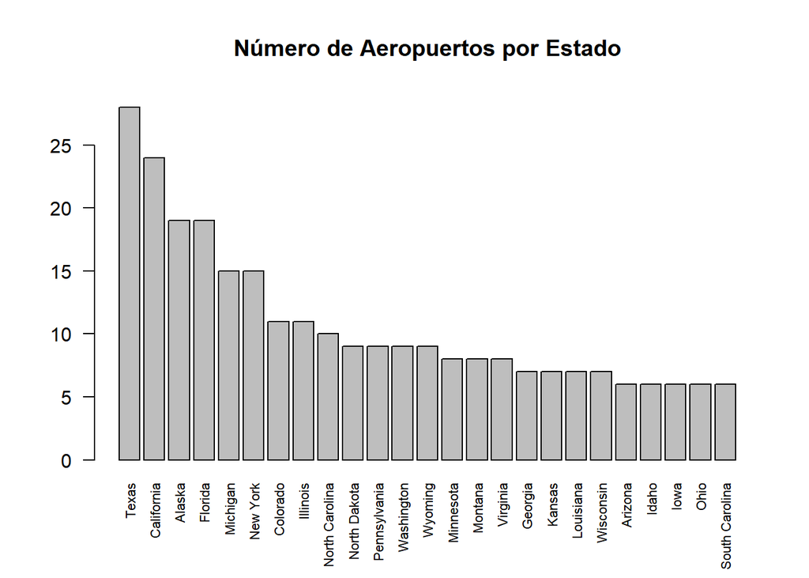

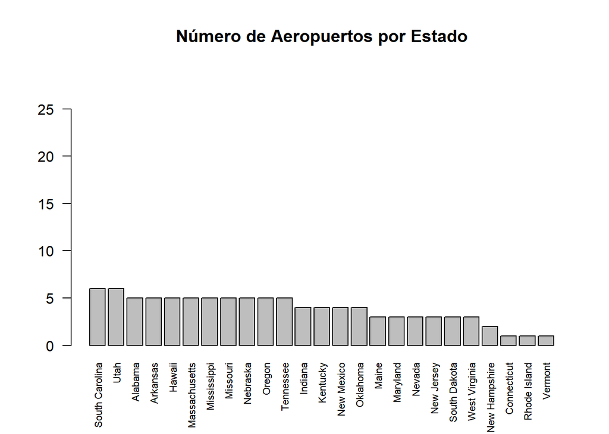

Como podemos observar en el gráfico, Texas es el Estado con más aeropuertos. El número de aeropuertos va disminuyendo progresivamente hasta los tres últimos estados (Connecticut, Rhode Island y Vermont). También podemos observar que el estado de Delaware no cuenta con ningun aeropuerto, por lo que no lo tendremos en cuenta en nuestro análisis.

A continuación vamos a realizar un mapa de calor el cual muestra cuantos aeropuertos hay por estado, teniendo en cuenta que los colores más oscuros son los estados con mayor número de aeropuerto y los más claros aquellos cuyo número de aeropuerto es menor. Para realizar el mapa de calor debemos leer un archivo shp el cual contiene el mapa de Estados Unidos. Otro paso que hemos tenido que realizar a la hora de hacer el mapa de calor ha sido el de juntar nuestra tabla con el fichero shp en función del nombre del estado. De manera que tenemos una tabla conjunta con toda la información anterior más las coordenadas de los límites de cada estado y así poder representar la información adecuadamente en el mapa.

```r
eeuu=st_read("C:/Users/ximoc/OneDrive - UPV/Escritorio/Proyecto 2/Estados_Unidos_Estados.shp")
names(eeuu)[names(eeuu) == "STATE_NAME"] <- "Estado"
shp_eeuu=merge(aer_est,eeuu,by="Estado")
shp_eeuu_sf <- st_as_sf(shp_eeuu)
tmap_mode("view")
```

```
## tmap mode set to interactive viewing
```

```r
tm_shape(shp_eeuu_sf)+
  tm_fill("Num_Aeropuertos",ID="Estado", palette="Reds", style="quantile",n=10, title="Aeropuetos totales")+
  tm_borders("grey25",alpha=0.5)+
  tm_layout("Número de Aeropuertos por Estado de EEUU 2023", main.title.position = "center")+
  tm_view(view.legend.position = c("left","bottom"))
```

[interactive chart not shown]

Gracias al mapa de calor, podemos ver de una forma más visual la información que nos proporcionaban los gráficos de barras anteriores.

## 2.2 Análisis de la Superfície por Aeropuerto

A continuación vamos a realizar otro mapa de calor que representa la superfície por aeropuerto. En este caso los colores más oscuros son los que más superfície tienen por aeropuerto.

```r
tmap_mode("view")
```

```
## tmap mode set to interactive viewing
```

```r
tm_shape(shp_eeuu_sf)+
  tm_fill("Ratio_sup_aer",ID="Estado", palette="Reds", style="quantile", n=10, title="Superfície por aeropuerto")+
  tm_borders("grey25",alpha=0.5)+
  tm_layout("Ratio de Superfíce (m^2) por Aeropuerto de cada Estado de EEUU 2023", main.title.position = "center")+
  tm_view(view.legend.position = c("left","bottom"))
```

[interactive chart not shown]

Podemos ver en el mapa como existe una tendencia donde los estados que tienen una mayor superficie por aeropuerto son a su vez los estados que tienen una mayor superfície. Aunque existen algunas excepciones como puede ser el estado de Vermont o Maine, las cuales a pesar de tener poca superfície tienen un ratio elevado ya que tienen un número muy bajo de aeropuertos.

## 2.3 Análisis de la Población por Aeropuerto

Una vez analizada la relacion entre la superficie y los aeropuertos pasaremos a analizar el ratio de población y aeropuertos. Para ello vamos a realizar un gráfico de barras el cual mostrará los 10 estados con mayor número de habitantes por aeropuerto. Además vamos a realizar dos tablas en las que podemos encontrar los 5 estados con mayor número de habitantes por aeropuerto y los 5 estados con menor ratio.

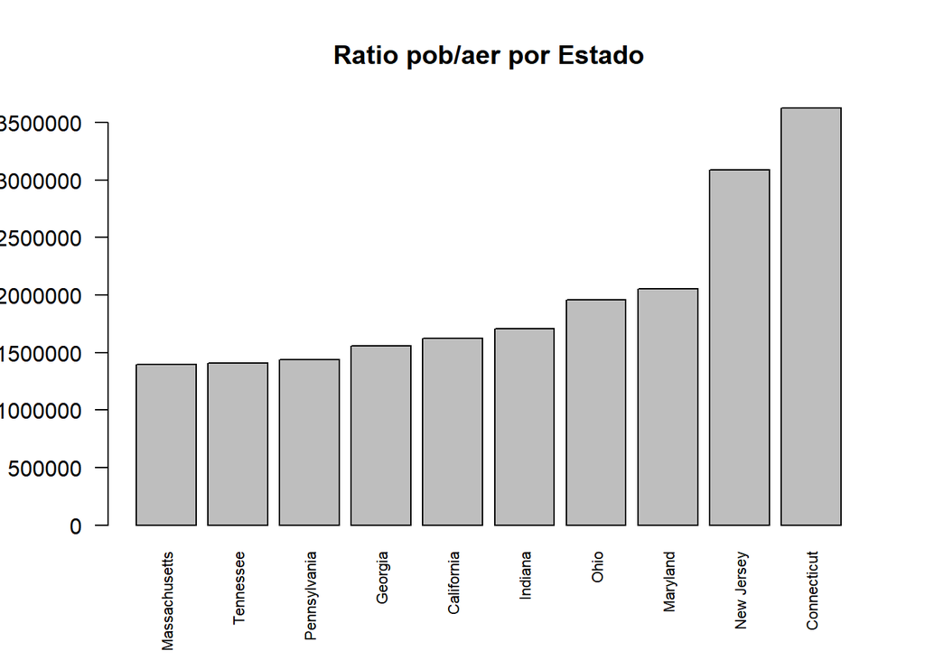

```r
aer_est_sort_1 <- aer_est[order(aer_est$Ratio_pob_aer), ]

primeros_10_estados <- head(aer_est_sort_1, 10)

ultimos_10_estados<- tail(aer_est_sort_1,10)
barplot(ultimos_10_estados$Ratio_pob_aer,
        xlab = "",
          ylim = c(0, max(aer_est$Ratio_pob_aer) + 1),

        names.arg = ultimos_10_estados$Estado,
        main = "Ratio pob/aer por Estado",
        las = 2,cex.names = 0.7)
```

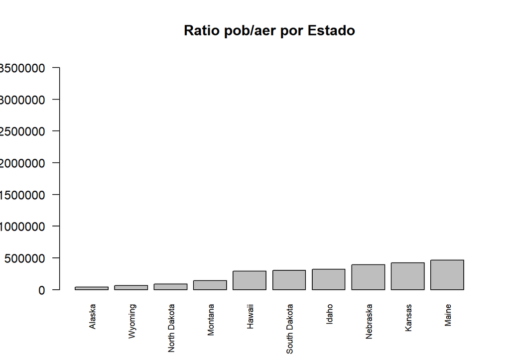

```r
barplot(primeros_10_estados$Ratio_pob_aer,
        xlab = "",
          ylim = c(0, max(aer_est$Ratio_pob_aer) + 1),

        names.arg = primeros_10_estados$Estado,
        main = "Ratio pob/aer por Estado",
        las = 2,cex.names = 0.7)
```

```r
top_5_menos_pers_per_aer=primeros_10_estados[2:6,c(1,6)]
top_5_mas_pers_per_aer=ultimos_10_estados[10:6,c(1,6)]
kable(top_5_menos_pers_per_aer)
```

|  | Estado | Ratio_pob_aer |
| --- | --- | --- |
| 49 | Wyoming | 64597.89 |
| 33 | North Dakota | 86584.56 |
| 25 | Montana | 140358.38 |
| 10 | Hawaii | 288039.20 |
| 40 | South Dakota | 303274.67 |

```r
kable(top_5_mas_pers_per_aer)
```

|  | Estado | Ratio_pob_aer |
| --- | --- | --- |
| 7 | Connecticut | 3626205 |
| 29 | New Jersey | 3087233 |
| 19 | Maryland | 2054887 |
| 34 | Ohio | 1959343 |
| 13 | Indiana | 1708259 |

Podemos observar como el estado con mayor ratio habitantes/aeropuerto es Connecticut con un valor de 3.626.205 hab/aer. Por otro lado, los dos estados con menor ratio son los de Alaska con 38609.63 habitantes por aeropuerto y Wyoming con 64597.89 hab/aer.

Ahora vamos a realizar otro mapa de calor que representa los habitantes por aeropuerto. En este caso los colores más oscuros son los que más habitantes tienen por aeropuerto.

```r
tmap_mode("view")
```

```
## tmap mode set to interactive viewing
```

```r
tm_shape(shp_eeuu_sf)+
  tm_fill("Ratio_pob_aer",ID="Estado", palette="Greens", style="quantile", n=10, title="Población por aeropuerto")+
  tm_borders("grey25",alpha=0.5)+
  tm_layout("Ratio de Población por Aeropuerto de cada Estado de EEUU 2023 ", main.title.position = "center")+
  tm_view(view.legend.position = c("left","bottom"))
```

[interactive chart not shown]

El mapa de calor verifica la información dada en las tablas anteriores, se puede observar como los paises que tienen un color más oscuro pertenecen a la tabla donde estan los cinco estados con mayor ratio poblacion/aeropuerto (Connecticut, New Jersey, Maryland, Ohio, Indiana); y los países con una tonalidad más clara coinciden con la tabla de los cinco estados con menor ratio pob/aer(Wyoming, North Dakota, Montana, Hawaii, South Dakota).

## 2.4 Análisis del Tráfico Aéreo

Ahora vamos a realizar un grafico de barras con la columna que agrupaba los estados segun el numero de vuelos para ver la distribuición que tienen dichos estados.

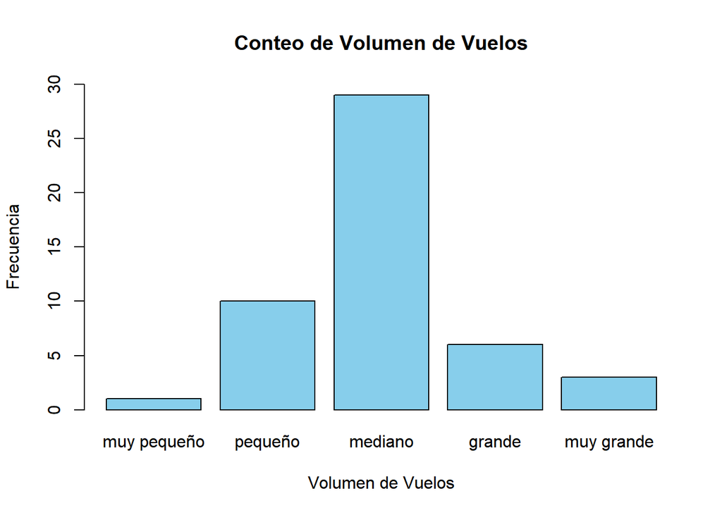

```r
aer_est$num_vuelos_discreta=cut(aer_est$`Numero de vuelos`,breaks=c(0,7500,25000,250000,500000,Inf),labels=c("muy pequeño", "pequeño","mediano","grande", "muy grande"))
conteos <- table(aer_est$num_vuelos_discreta)


barplot(conteos, main = "Conteo de Volumen de Vuelos", xlab = "Volumen de Vuelos", ylab = "Frecuencia", col = "skyblue", ylim = c(0, max(conteos) + 1))
```

Para finalizar con los mapas de calor en este objetivo, vamos a realizar uno sobre el tráfico aéreo. Para ello vamos vamos a utilizar el número de vuelos que ha habido por estado en 2023.

```r
colores <- c("muy pequeño" = "lightgrey", "pequeño" = "lightblue", "mediano" = "lightgreen", "grande" = "salmon", "muy grande" = "red")
tmap_mode("view")
```

```
## tmap mode set to interactive viewing
```

```r
tm_shape(shp_eeuu_sf)+
  tm_fill(col="num_vuelos_discreta", palette=colores, style="cat", title="Volumen de tráfico aéreo")+
  tm_borders("grey25",alpha=0.5)+
  tm_layout("Volumen de Vuelos por cada Estado de EEUU 2023 ", main.title.position = "center")+
  tm_view(view.legend.position = c("left","bottom"))
```

[interactive chart not shown]

Se puede observar como los estados costeros son los que más densidad de vuelos tienen mientras que los estados que se ubican en el interior del país tienen menos vuelos. Esto se puede deber a que en los estados costeros existe un mayor turismo y por tanto hay una mayor afluencia de gente. También es de considerar que estos estados actúan como estados puente, es decir, que reciben un gran número de vuelos internacionales y después se desplazan a cualquier parte del país mediante un vuelo nacional desde el propio aeropuerto del estado. Aun así existen estados que no cumplen con esta regla, tenemos el ejemplo de Colorado que se encuentra en el interior del país y aun así tiene mucha densidad de vuelos, también observamos como Maine a pesar de ser un estado costero no cuenta con una gran cantidad de vuelos.

# 3. PCA

Para finalizar con el objetivo vamos a realizar un PCA de nuestra base de datos para ver si existen relaciones entre las variables y observaciones. Para ello, primero vamos a realizar una tabla auxiliar de variables incluyendo el tipo de cada una. La base de datos que utilizamos tiene 2 variables categóricas y 6 variables numéricas

```r
descAer = data.frame("variable" = colnames(aer_est),
                      "tipo" = c("categorical",
                                 rep("numerical", 6),"categorical"))
rownames(descAer) = descAer$variable
```

## 3.1 Selección del número de PCs

A continuación, mediante un scree plot y utlizando diferentes criterios determinaremos el número de componentes principales para nuestros datos. Introduciremos al modelo las variables que sean de tipo numérico y utilizaremos las categóricas como variables auxiliares (**Estado** y **num_vuelos_discreta**)

```r
library(FactoMineR)
library(factoextra)
```

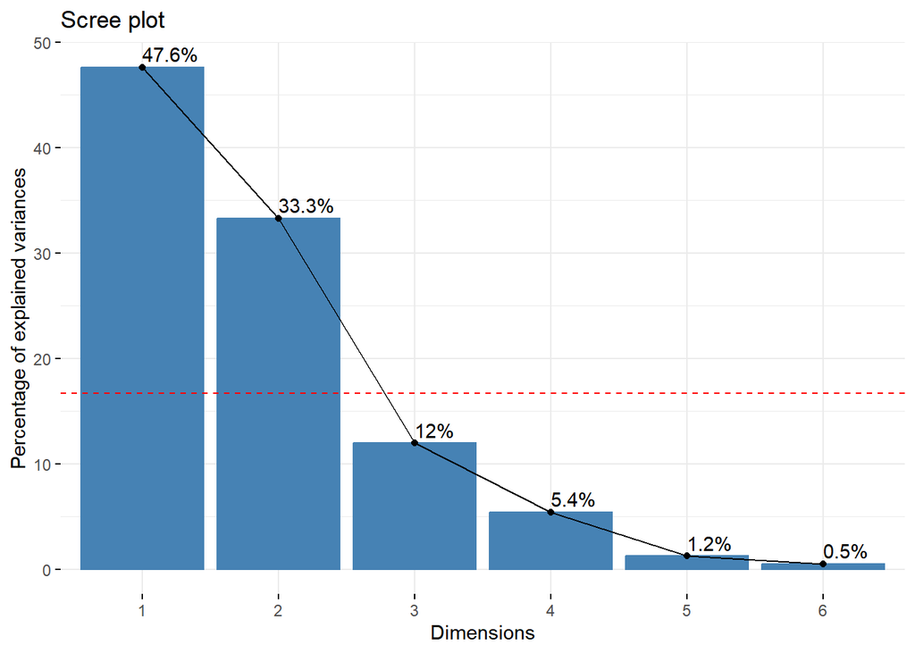

```r
res.pca = PCA(aer_est, scale.unit = T, graph = FALSE, ncp = 6,
              quali.sup = which(descAer$tipo == "categorical"))
eig.val <- get_eigenvalue(res.pca)
VPmedio = 100 * (1/nrow(eig.val))
fviz_eig(res.pca, addlabels = TRUE) +
  geom_hline(yintercept=VPmedio, linetype=2, color="red")
```

```r
kable(eig.val[1:6,])
```

|  | eigenvalue | variance.percent | cumulative.variance.percent |
| --- | --- | --- | --- |
| Dim.1 | 2.8582781 | 47.6379683 | 47.63797 |
| Dim.2 | 1.9970986 | 33.2849774 | 80.92295 |
| Dim.3 | 0.7171346 | 11.9522436 | 92.87519 |
| Dim.4 | 0.3250161 | 5.4169349 | 98.29212 |
| Dim.5 | 0.0742529 | 1.2375476 | 99.52967 |
| Dim.6 | 0.0282197 | 0.4703283 | 100.00000 |

A partir del scree plot y empleando el criterio del codo, podemos observar que las 2 primeras PC’s formarán parte del modelo. Con dos componentes principales la variabilidad explicada es de un 80,9%.

Ahora realizamos el PCA con 2 componentes principales.

```r
K=2
res.pca = PCA(aer_est, scale.unit = TRUE, graph = FALSE, ncp = K,
              quali.sup = which(descAer$tipo == "categorical"))
```

## 3.2 Validación del modelo PCA

Para identificar los valores anómalos extremos utilizaremos el estadístico T^2-Hotelling. Ahora, vamos a visualizar el gráfico con los valores de cada observación para este estadístico. Además, añadiremos los límites de confianza del 95% (naranja) y 99% (rojo) para identificar los anómalos más fácilmente.

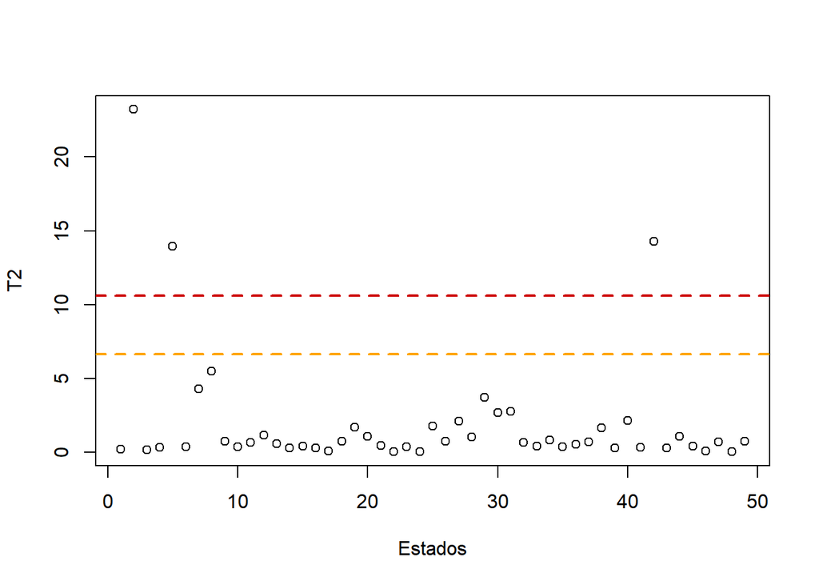

```r
misScores = res.pca$ind$coord[,1:K]
miT2 = colSums(t(misScores**2)/eig.val[1:K,1])
I = nrow(aer_est)
F95 = K*(I**2 - 1)/(I*(I - K)) * qf(0.95, K, I-K)
F99 = K*(I**2 - 1)/(I*(I - K)) * qf(0.99, K, I-K)

plot(1:length(miT2), miT2, type = "p", xlab = "Estados", ylab = "T2")
abline(h = F95, col = "orange", lty = 2, lwd = 2)
abline(h = F99, col = "red3", lty = 2, lwd = 2)
```

Observando el gráfico, podemos ver como hay 3 observaciones por encima del límite del 95% de confianza y a su vez también están por encima del límite del 99%. Vamos a observar estas 3 observaciones.

```r
anomalas = which(miT2 > F95)
anomalas
```

```
##  2  5 42
##  2  5 42
```

Representamos los scores en función de si superan el limite del 95% (y del 99% ya que todas las observaciones que superan el limite de 95% también superan el de 99%).

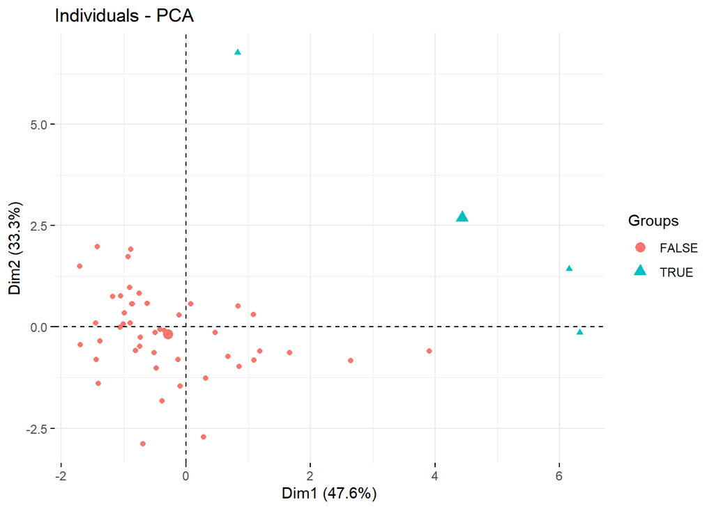

```r
library(grid)
library(gridExtra)


p1 = fviz_pca_ind(res.pca, axes = c(1,2), geom = c("point"),
                  habillage = factor(miT2 > F95))



grid.arrange(p1, nrow = 1)
```

Podemos observar que de las 3 observaciones que superan el límite del 95% y del 99% hay dos de ellas que tienen valores muy altos para las variables de la primera componente principal mientras que para la segunda componente sus valores estan en la media, y la otra observación tiene valores muy altos para las variables de la segunda componente principal mientras que la los valores de la primera componente se mantienen en la media.

Vamos a observar cada una de estas observaciones como se ven afectadas por cada dimensión

```r
contribT2 = function (X, scores, loadings, eigenval, observ, cutoff = 2) {
  # X is data matrix and must be centered (or centered and scaled if data were scaled)
  misScoresNorm = t(t(scores**2) / eigenval)
  misContrib = NULL
  for (oo in observ) {
    print(rownames(misScores)[oo])
    print(misScores[oo,])
    misPCs = which(as.numeric(misScoresNorm[oo,]) > cutoff)
    lacontri = sapply(misPCs, function (cc) (misScores[oo,cc]/eigenval[cc])*loadings[,cc]*X[oo,])
    lacontri = rowSums((1*(sign(lacontri) == 1))*lacontri)
    misContrib = cbind(misContrib, lacontri)
  }
  colnames(misContrib) = rownames(misScoresNorm[observ,])
  return(misContrib)
}
```

```r
# Recuperamos los datos utilizados en el modelo PCA, centrados y escalados
aerCE = aer_est[,descAer$tipo == "numerical"]
aerCE = scale(aerCE, center = TRUE, scale = TRUE)
X = as.matrix(aerCE)
# Calculamos los loadings a partir de las coordenadas de las variables
# ya que la librería FactoMineR nos devuelve los loadings ponderados
# por la importancia de cada componente principal.
misLoadings = sweep(res.pca$var$coord, 2, sqrt(res.pca$eig[1:K,1]), FUN="/")
# Calculamos las contribuciones
mycontrisT2_2 = contribT2(X = X, scores = misScores, loadings = misLoadings,
                        eigenval = eig.val[1:K,1], observ = 2,
                        cutoff = 2)
```

```
## [1] "2"
##     Dim.1     Dim.2
## 0.8318357 6.7736890
```

```r
mycontrisT2_5 = contribT2(X = X, scores = misScores, loadings = misLoadings,
                        eigenval = eig.val[1:K,1], observ = 5,
                        cutoff = 2)
```

```
## [1] "5"
##      Dim.1      Dim.2
##  6.3176171 -0.1337738
```

```r
mycontrisT2_42 = contribT2(X = X, scores = misScores, loadings = misLoadings,
                        eigenval = eig.val[1:K,1], observ = 42,
                        cutoff = 2)
```

```
## [1] "42"
##    Dim.1    Dim.2
## 6.150578 1.433510
```

Se puede comprobar como se verifica la información anterior.

Para saber porque las observaciones son anómalas debemos saber cual es la variable que hace que tenga un score extremo. Para ello vamos a ver la contribuicion de cada variable para las observaciones que superan el límite del 95% y 99%. Sabemos que la observación 2 es Alaska, la observación 5 es California y la observación 42 es Texas.

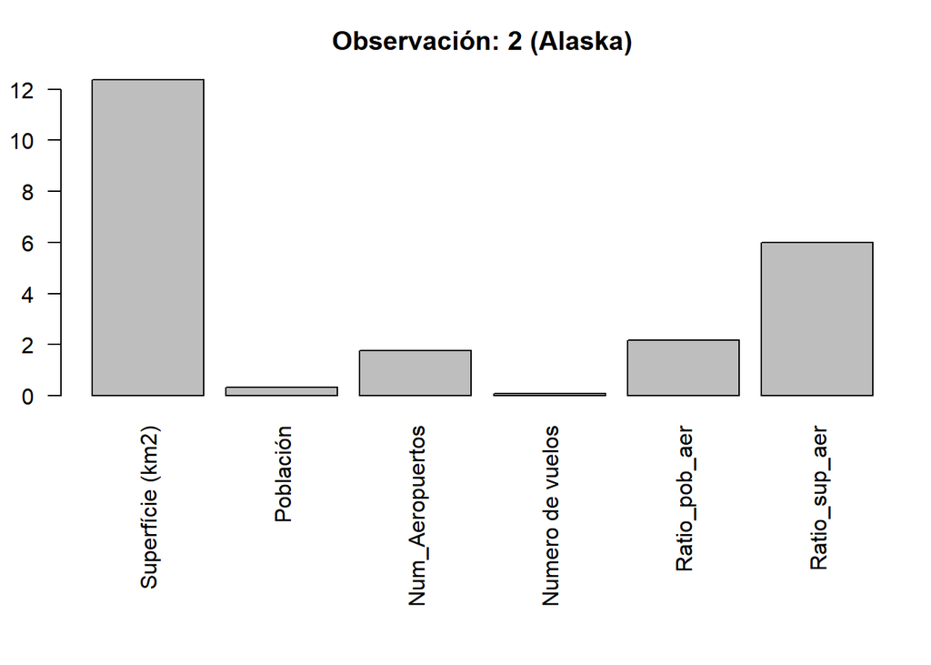

```r
par(mar = c(10,2.3,3,1))
barplot(mycontrisT2_2[,1],las=2, #cex.names = 0.5,
        main= paste0("Observación: 2 (Alaska)"))
```

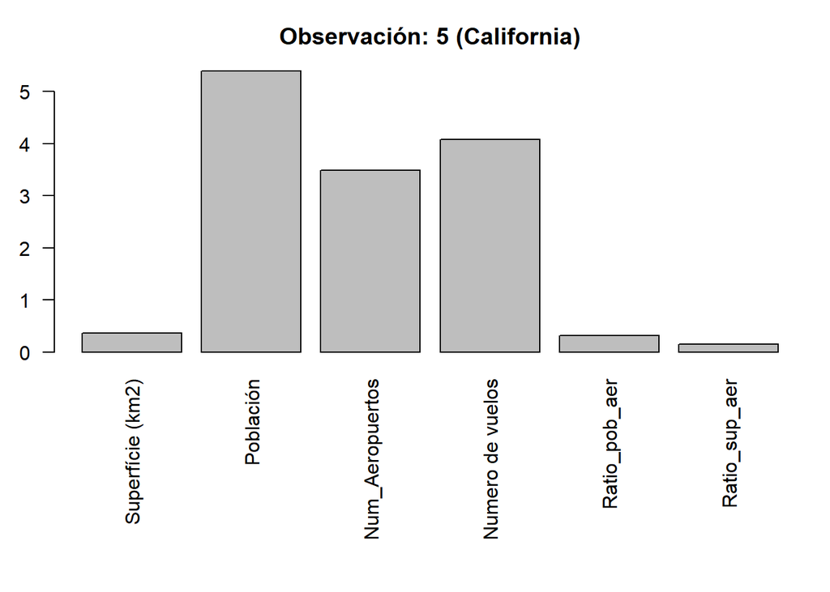

```r
par(mar = c(10,2.3,3,1))
barplot(mycontrisT2_5[,1],las=2, #cex.names = 0.5,
        main= paste0("Observación: 5 (California)"))
```

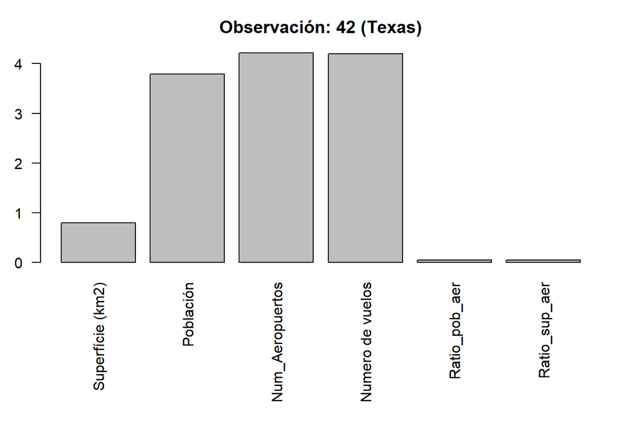

```r
par(mar = c(10,2.3,3,1))
barplot(mycontrisT2_42[,1],las=2, #cex.names = 0.5,
        main= paste0("Observación: 42 (Texas)"))
```

Viendo los gráficos de contribuición podemos deducir que Alaska es un valor atípico en mayor medida por la variable superficie (este estado tiene una gran superfucie de tierra), California es atípico debido a las variables **Población**, **num_aeropuertos** y **numero_de_vuelos** (primera componente principal, lo veremos más tarde) que contribuyen de una manera muy similar (Población contribuye un poco más que las demás, pero no mucho), y Texas es atípico por las variables **Población**, **num_aeropuertos** y **numero_de_vuelos**, que contribuyen en la misma medida.

Ahora estudiaremos la distancia al modelo PCA mediante la Suma de Cuandrados Residual (SCR) para detectar valores anómalos moderados. En primer lugar creamos la matriz de residuos y calculamos la SCR de cada observacion a partir de ella. Y lo representamos visualmente.

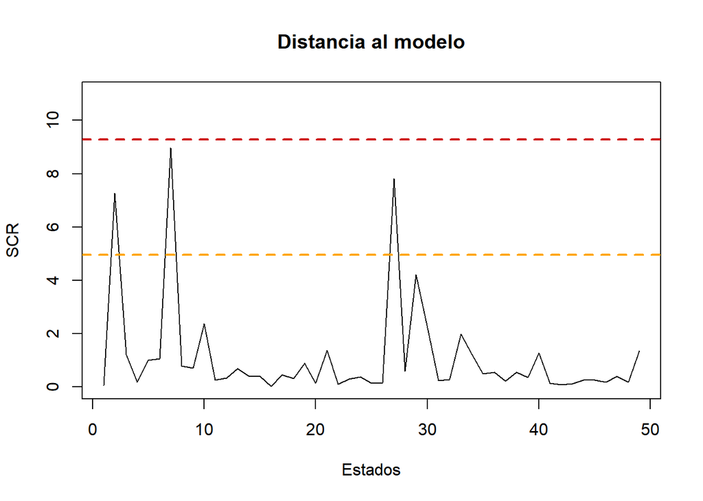

```r
myE = X - misScores %*% t(misLoadings)
mySCR = rowSums(myE^2)
plot(1:length(mySCR), mySCR, type = "l", main = "Distancia al modelo",
     ylab = "SCR", xlab = "Estados", ylim = c(0,11))
g = var(mySCR)/(2*mean(mySCR))
h = (2*mean(mySCR)^2)/var(mySCR)
chi2lim = g*qchisq(0.95, df = h)
chi2lim99 = g*qchisq(0.99, df = h)
abline(h = chi2lim, col = "orange", lty = 2, lwd = 2)
abline(h = chi2lim99, col = "red3", lty = 2, lwd = 2)
```

```r
a_mod<- which(mySCR>chi2lim)
a_mod
```

```
## [1]  2  7 27
```

Podemos observar en el gráfico como ninguna observacion supera el limite del 99%, y solo 3 el limite del 95%, estos podrían considerarse valores anómalos moderados por lo que vamos a analizar la contribuición de cada variable a estas observaciones.

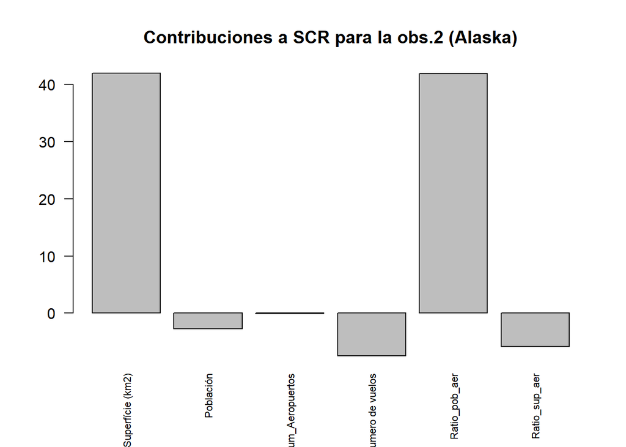

```r
ContriSCR = function(E, SCR) {
  # E es la matriz de residuos del modelo
  # SCR es la suma de cuadrados residual
  contribucion = NULL
  for (j in 1:length(SCR)){
    eind<-E[j,]
    signo<-sign(eind)
    contri<-(signo*(eind^2)/SCR[j])*100
    contribucion<-rbind(contribucion,contri)
  }
  rownames(contribucion) = rownames(E)
  return(contribucion)
}
## Calculamos las contribuciones de todas las observaciones
mycontris = ContriSCR(E = myE, SCR = mySCR)
## Gráfico para Special_K
barplot(mycontris[2,],las=2, cex.names = 0.7,
        main=c('Contribuciones a SCR para la obs.2 (Alaska)'))
```

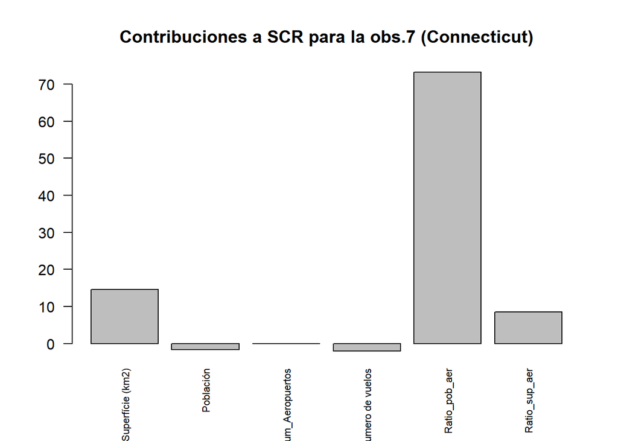

```r
barplot(mycontris[7,],las=2, cex.names = 0.7,
        main=c('Contribuciones a SCR para la obs.7 (Connecticut)'))
```

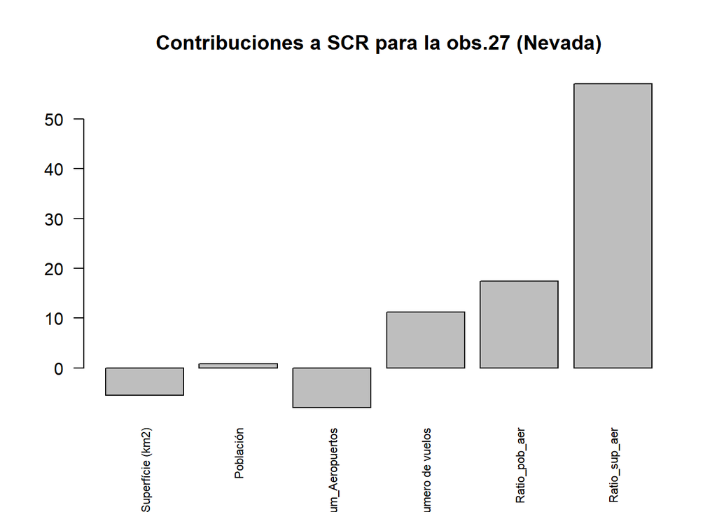

```r
barplot(mycontris[27,],las=2, cex.names = 0.7,
        main=c('Contribuciones a SCR para la obs.27 (Nevada)'))
```

## 3.3 Interpretación del modelo PCA

A continuación vamos a realizar un gráfico de loading para poder observar las relaciones que hay entre las variables y para ver como contribuyen cada una a las componentes principales y las coloreamos según su contribuición.

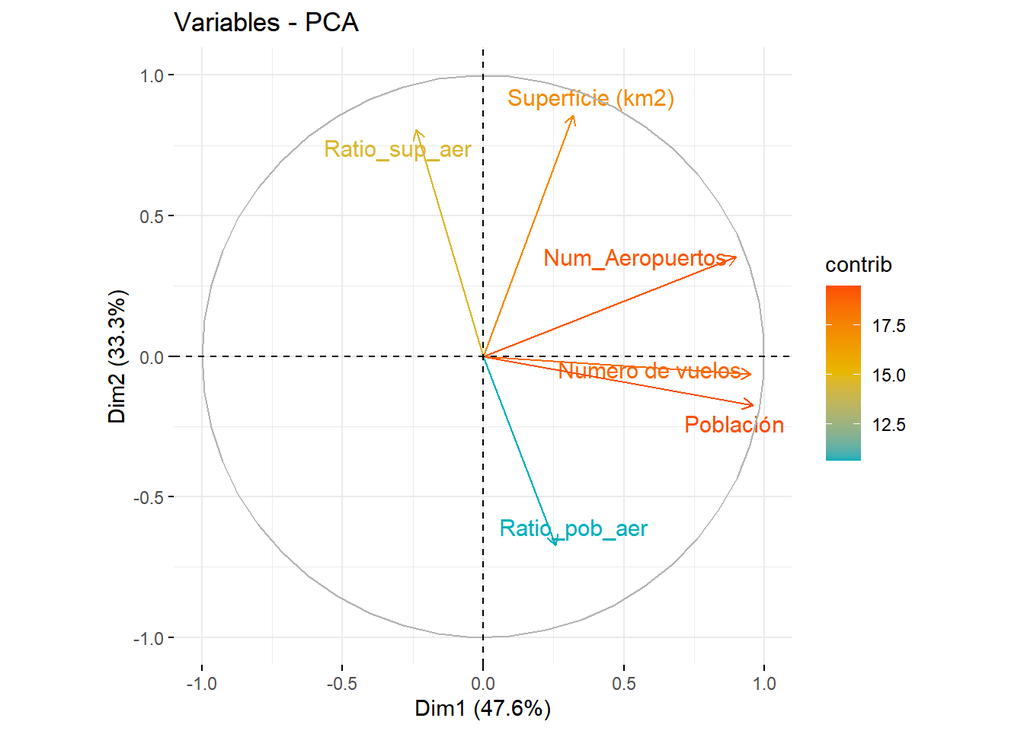

```r
fviz_pca_var(res.pca, axes = c(1,2), repel = TRUE, col.var = "contrib",
             gradient.cols = c("#00AFBB", "#E7B800", "#FC4E07"))
```

Las variables que más contribuyen en la PC1 son las variables **Población**, **num_aeropuertos** y **numero_de_vuelos** que estan correlacionadas positivante entre ellas, es decir, si el valor en una de estas variables es alto, en el de las otras variables correlacionadas también será alto.

En cambio para la PC2 las variables que más contribuyen son **Superficie**, **Ratio_sup_aer** y **ratio_pob_aer**. **Superficie** y **Ratio_sup_aer** están correlacionadas positivamente entre si, pero estas dos estan correlacionadas negativamente con **ratio_pob_aer**.

A continuación, generamos gráficos de dispersión para comprobar las hipótesis sobre relaciones entre variables sugeridas por el PCA:

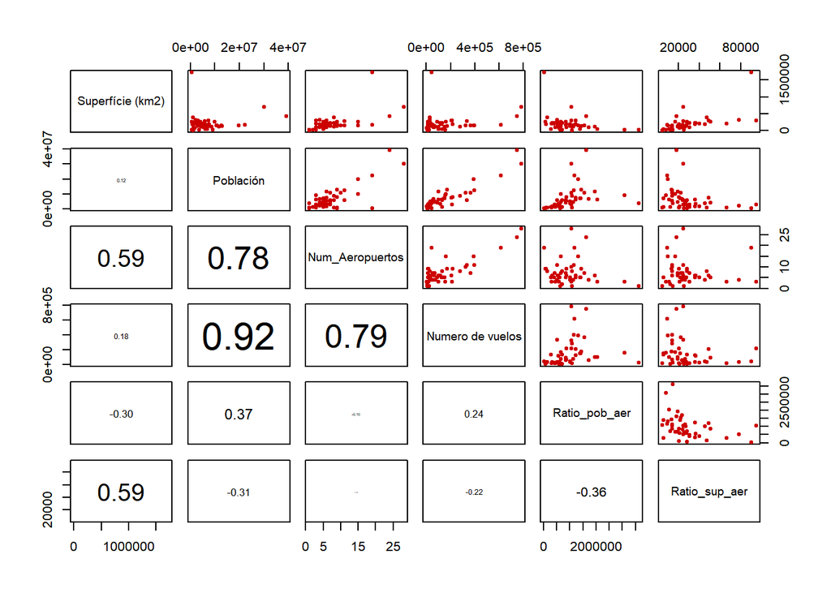

```r
panel.cor <- function(x, y, digits = 2, prefix = "", cex.cor, ...)
{
    par(usr = c(0, 1, 0, 1))
    r <- cor(x, y)
    txt <- format(c(r, 0.123456789), digits = digits)[1]
    txt <- paste0(prefix, txt)
    if(missing(cex.cor)) cex.cor <- 0.8/strwidth(txt)
    text(0.5, 0.5, txt, cex = cex.cor * abs(r))
}
pairs(aer_est[,c("Superfície (km2)", "Población", "Num_Aeropuertos", "Numero de vuelos", "Ratio_pob_aer", "Ratio_sup_aer")],
      lower.panel = panel.cor, pch = 20, col = "red3")
```

Podemos observar como se verifica la información obtenida en el gráfico de loadings. Vemos como **Población**, **num_aeropuertos** y **numero_de_vuelos** estan relacionadas positivamente de una manera fuerte entre ellas, con un coeficiente de 0.78, 0,92, 0.79 (valores positivos y cercanos a 1). Y tambien vemos como **Superficie** y **Ratio_sup_aer** estan relacionadas positivamente (0.59), y a su vez estas 2 variables estan negativamente correlacionadas con **Ratio_pob_aer** (-0.36 y -0.30)

Para dejar más claro la contribución de cada variable a las dos componentes principales, vamos a ver dos gráficos de barras con la contribución.

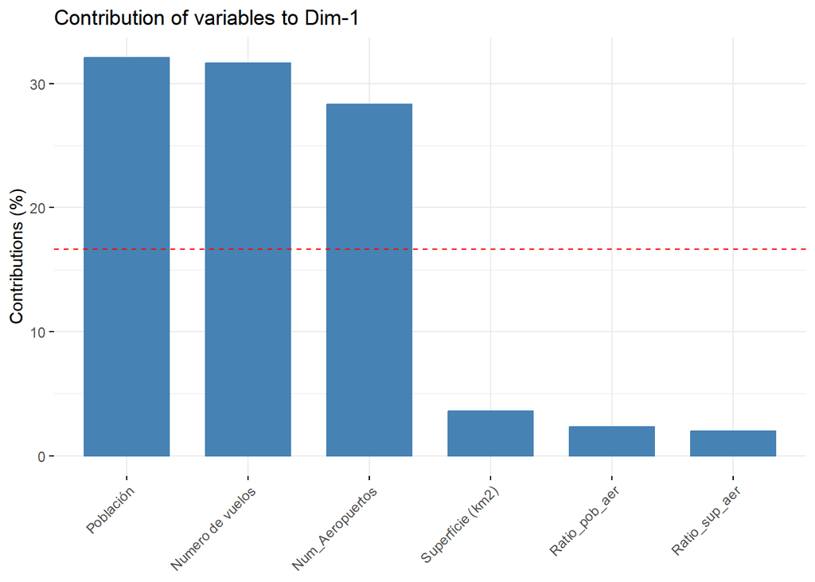

```r
fviz_contrib(res.pca, choice = "var", axes = 1)
```

Para la primera componente principal las variables que más contribuyen son **Población**, **num_aeropuertos** y **numero_de_vuelos**, mientras que las otras no contribuyen de manera significativa.

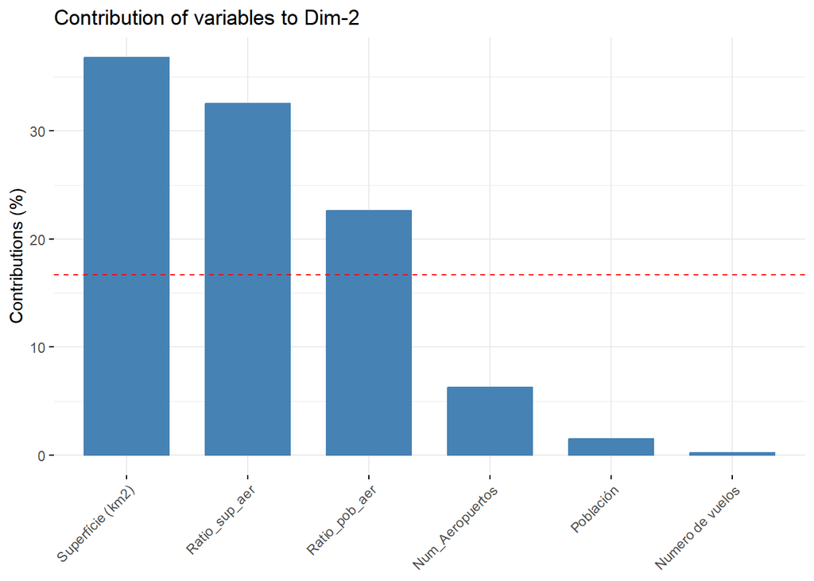

```r
fviz_contrib(res.pca, choice = "var", axes = 2)
```

Para la segunda componente principal las variables que más contribuyen son **Superficie**, **Ratio_sup_aer** y **ratio_pob_aer**, mientras que las otras no contribuyen de manera significativa.

Ahora vamos a realizar un gráfico de scores el cual nos permitirá visualizar el comportamiento de los estados y las relaciones que hay entre ellos.

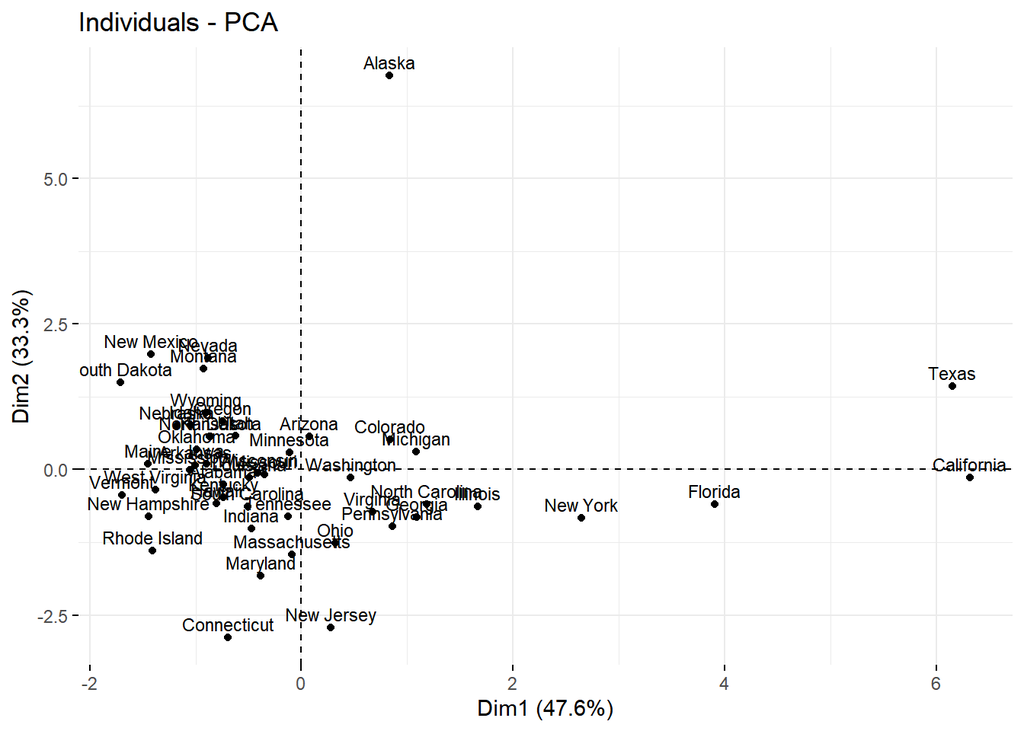

```r
library(factoextra)

# Convertir las coordenadas PCA en un dataframe
pca_coords <- as.data.frame(res.pca$ind$coord)

# Agregar los nombres de los estados al dataframe de coordenadas PCA
pca_coords$Estado <- aer_est$Estado

# Generar el gráfico de scores del PCA con etiquetas de los estados
fviz_pca_ind(res.pca, axes = c(1, 2), geom = c("point"), label = "ind", labelsize = 2) +
  geom_text(data = pca_coords, aes(x = Dim.1, y = Dim.2, label = Estado), size = 3, vjust = -0.5)
```